# Data Mining - Predicting Customer Churn

Author: Eduardo Bayego Modrego

January 2024

# 1 Data cleaning

First, we import the processed set, with clean, quality and discretized variables.

```r
set.seed(333)
telecomCleanData <- read.csv("./telecomCleanData.csv")
```

Let’s first check that we have all the data clean and of good quality, in order to be able to apply the different algorithms correctly, such as kmeans.

```r
print('NA')
```

```
## [1] "NA"
```

```r
colSums(is.na(telecomCleanData))
```

```
##                       Customer.ID                            Gender
##                                 0                                 0
##                               Age                           Married
##                                 0                                 0
##              Number.of.Dependents                              City
##                                 0                                 0
##                          Zip.Code               Number.of.Referrals
##                                 0                                 0
##                  Tenure.in.Months                             Offer
##                                 0                                 0
##                     Phone.Service Avg.Monthly.Long.Distance.Charges
##                                 0                               682
##                    Multiple.Lines                  Internet.Service
##                                 0                                 0
##                     Internet.Type           Avg.Monthly.GB.Download
##                                 0                                 0
##                   Online.Security                     Online.Backup
##                                 0                                 0
##            Device.Protection.Plan              Premium.Tech.Support
##                                 0                                 0
##                      Streaming.TV                  Streaming.Movies
##                                 0                                 0
##                   Streaming.Music                    Unlimited.Data
##                                 0                                 0
##                          Contract                 Paperless.Billing
##                                 0                                 0
##                    Payment.Method                    Monthly.Charge
##                                 0                                 0
##                     Total.Charges                     Total.Refunds
##                                 0                                 0
##          Total.Extra.Data.Charges       Total.Long.Distance.Charges
##                                 0                                 0
##                     Total.Revenue                   Customer.Status
##                                 0                                 0
##                    Churn.Category                      Churn.Reason
##                                 0                                 0
##                   Tenure_Category                      Age_Category
##                                 0                                 0
##                  Service_Category
##                                94
```

```r
print('White')
```

```
## [1] "White"
```

```r
colSums(telecomCleanData=="")
```

```
##                       Customer.ID                            Gender
##                                 0                                 0
##                               Age                           Married
##                                 0                                 0
##              Number.of.Dependents                              City
##                                 0                                 0
##                          Zip.Code               Number.of.Referrals
##                                 0                                 0
##                  Tenure.in.Months                             Offer
##                                 0                                 0
##                     Phone.Service Avg.Monthly.Long.Distance.Charges
##                                 0                                NA
##                    Multiple.Lines                  Internet.Service
##                               682                                 0
##                     Internet.Type           Avg.Monthly.GB.Download
##                                 0                                 0
##                   Online.Security                     Online.Backup
##                                 0                                 0
##            Device.Protection.Plan              Premium.Tech.Support
##                                 0                                 0
##                      Streaming.TV                  Streaming.Movies
##                                 0                                 0
##                   Streaming.Music                    Unlimited.Data
##                                 0                                 0
##                          Contract                 Paperless.Billing
##                                 0                                 0
##                    Payment.Method                    Monthly.Charge
##                                 0                                 0
##                     Total.Charges                     Total.Refunds
##                                 0                                 0
##          Total.Extra.Data.Charges       Total.Long.Distance.Charges
##                                 0                                 0
##                     Total.Revenue                   Customer.Status
##                                 0                                 0
##                    Churn.Category                      Churn.Reason
##                              3761                              3761
##                   Tenure_Category                      Age_Category
##                                 0                                 0
##                  Service_Category
##                                NA
```

We see that there are values in two fields with null values, so we eliminate them without any problem, since the number is not very high and we still have a good amount of data.

```r
telecomCleanData <- na.omit(telecomCleanData)
```

# 2 Unsupervised Model

Now that we have the data 100% clean (since the empty texts will not be a problem when applying the algorithm), we have 2 ways to approach the problem: apply kmodes, or apply kmeans, in which we have to transform the categorical variables to numerical, so we would have to check the different values of each variable and assign a number, writing them down in a separate note that serves as a legend for when we want to analyze the results. After many tests with kmodes, I have observed that it gives many errors and failures and no accurate conclusion, and also, because the categorical variable “City” is the most problematic because it takes many different values, we can eliminate this and use Zip.Code (zip code), because for practical purposes, it is the same (if there was a zip code in which all were out of the company, it would mean that there is an area of a city in which, for example, it is possible that the telephone connection is bad. This is actually more accurate than filtering by cities). We can analyze the value of these two variables in our predictive model, to see if Zip.Code has equal or greater value than “City”. If so, we can be sure to use only Zip.Code to make the task easier.

```r
if(!require('DescTools')) install.packages('DescTools'); library('DescTools')
#We use only Phi or CramerV, because being 2x2 it will always be the same value one as the other
variables_predictoras <- names(telecomCleanData)[names(telecomCleanData) != "Customer.Status"]
for (variable in variables_predictoras) {
  cat("\n")
  print(variable)
  print(Phi(table(telecomCleanData[[variable]], telecomCleanData$Customer.Status)))
}
```

```
##
## [1] "Customer.ID"
## [1] 1.414214
##
## [1] "Gender"
## [1] 0.01544785
##
## [1] "Age"
## [1] 0.1954605
##
## [1] "Married"
## [1] 0.2393467
##
## [1] "Number.of.Dependents"
## [1] 0.2580949
##
## [1] "City"
## [1] 0.7070914
##
## [1] "Zip.Code"
## [1] 0.8582937
##
## [1] "Number.of.Referrals"
## [1] 0.4085337
##
## [1] "Tenure.in.Months"
## [1] 0.7546122
##
## [1] "Offer"
## [1] 0.4049771
##
## [1] "Phone.Service"
## [1] 0.7034145
##
## [1] "Avg.Monthly.Long.Distance.Charges"
## [1] 1.13565
##
## [1] "Multiple.Lines"
## [1] 0.1815746
##
```

[output cut: 59 more lines]

```
##
## [1] "Churn.Category"
## [1] 1
##
## [1] "Churn.Reason"
## [1] 1
##
## [1] "Tenure_Category"
## [1] 0.7034145
##
## [1] "Age_Category"
## [1] 0.1068969
##
## [1] "Service_Category"
## [1] 0.2369847
```

With this data we can draw several initial conclusions, although they will be analyzed later, here for the moment we only want to see the value of City and Zip.Code, and we observe that we can effectively eliminate City and stay with Zip.Code, and transform the rest of variables to numerical. We can also eliminate the id of the client, since this does not mean anything in our analysis.

```r
telecomCleanData <- subset(telecomCleanData, select = -c(City, Customer.ID))

for (columna in names(telecomCleanData)) {
  if (is.character(telecomCleanData[[columna]])) {
    cat("Variable:", columna, "\n")
    cat("Valores únicos:", unique(telecomCleanData[[columna]]), "\n")
    cat("\n")
  }
}
```

```
## Variable: Gender
## Valores únicos: Female Male
##
## Variable: Married
## Valores únicos: Yes No
##
## Variable: Offer
## Valores únicos: None Offer E Offer D Offer A Offer B Offer C
##
## Variable: Phone.Service
## Valores únicos: Yes
##
## Variable: Multiple.Lines
## Valores únicos: No Yes
##
## Variable: Internet.Service
## Valores únicos: Yes
##
## Variable: Internet.Type
## Valores únicos: Cable Fiber Optic DSL
##
## Variable: Online.Security
## Valores únicos: No Yes
##
## Variable: Online.Backup
## Valores únicos: Yes No
##
## Variable: Device.Protection.Plan
## Valores únicos: No Yes
##
## Variable: Premium.Tech.Support
## Valores únicos: Yes No
##
## Variable: Streaming.TV
## Valores únicos: Yes No
##
## Variable: Streaming.Movies
## Valores únicos: No Yes
##
## Variable: Streaming.Music
```

[output cut: 16 more lines]

```
##
## Variable: Churn.Category
## Valores únicos:  Competitor Dissatisfaction Other Attitude Price
##
## Variable: Churn.Reason
## Valores únicos:  Competitor had better devices Product dissatisfaction Network reliability Limited range of services Don't know Competitor made better offer Competitor offered higher download speeds Attitude of service provider Attitude of support person Lack of affordable download/upload speed C…
##
## Variable: Tenure_Category
## Valores únicos: Junior
##
## Variable: Age_Category
## Valores únicos: Adulto Anciano Joven
##
## Variable: Service_Category
## Valores únicos: Services with Improvements All Included Enhanced Services Minimum Services
```

```r
telecomNumericData <- telecomCleanData

variables_siono <- c("Married", "Phone.Service", "Multiple.Lines", "Internet.Service", "Online.Security", "Online.Backup", "Device.Protection.Plan", "Premium.Tech.Support", "Streaming.TV", "Streaming.Movies", "Streaming.Music", "Unlimited.Data", "Paperless.Billing")

for (variable in variables_siono) {
  telecomNumericData[[variable]] <- ifelse(telecomNumericData[[variable]] == "Yes", 1, 0)
}

lista_leyendas <- list()
lista_leyendas[["legend_Yes_No"]] <- data.frame(Valor_Numerico = c(0, 1), Leyenda = c("No", "Yes"))

for (columna in names(telecomNumericData)) {
  if (is.character(telecomNumericData[[columna]])) {
    telecomNumericData[[columna]] <- factor(telecomNumericData[[columna]], levels = unique(telecomNumericData[[columna]]))

    leyenda <- levels(telecomNumericData[[columna]])
    leyenda <- factor(leyenda)
    leyenda_numerica <- as.numeric(leyenda)
    lista_leyendas[[paste0("legend_", columna)]] <- data.frame(Valor_Numerico = leyenda_numerica, Leyenda = leyenda)

    telecomNumericData[[columna]] <- as.numeric(telecomNumericData[[columna]])
  }
}

for (nombre_dataset in names(lista_leyendas)) {
  cat("Data from", nombre_dataset, ":\n")
  print(lista_leyendas[[nombre_dataset]])
  cat("\n")
}
```

```
## Data from legend_Yes_No :
##   Valor_Numerico Leyenda
## 1              0      No
## 2              1     Yes
##
## Data from legend_Gender :
##   Valor_Numerico Leyenda
## 1              1  Female
## 2              2    Male
##
## Data from legend_Offer :
##   Valor_Numerico Leyenda
## 1              1    None
## 2              6 Offer E
## 3              5 Offer D
## 4              2 Offer A
## 5              3 Offer B
## 6              4 Offer C
##
## Data from legend_Internet.Type :
##   Valor_Numerico     Leyenda
## 1              1       Cable
## 2              3 Fiber Optic
## 3              2         DSL
##
## Data from legend_Contract :
##   Valor_Numerico        Leyenda
## 1              2       One Year
## 2              1 Month-to-Month
## 3              3       Two Year
##
## Data from legend_Payment.Method :
##   Valor_Numerico         Leyenda
## 1              2     Credit Card
## 2              1 Bank Withdrawal
## 3              3    Mailed Check
##
## Data from legend_Customer.Status :
##   Valor_Numerico Leyenda
## 1              3  Stayed
```

[output cut: 37 more lines]

```
##   Valor_Numerico Leyenda
## 1              1  Junior
##
## Data from legend_Age_Category :
##   Valor_Numerico Leyenda
## 1              1  Adulto
## 2              2 Anciano
## 3              3   Joven
##
## Data from legend_Service_Category :
##   Valor_Numerico                    Leyenda
## 1              4 Services with Improvements
## 2              1               All Included
## 3              2          Enhanced Services
## 4              3           Minimum Services
```

In this last code we have created a new dataset to store all the numerical variables, we have modified all the variables that were of “Yes” or “No” by their respective number 1 and 0, we have also created a list to store all the datasets that contain all the legends of the numerical value of the variables to understand well the results of the analysis that we are doing, and then we have modified the rest of the variables to numerical.

Now we can see which cluster value is the best to separate the data by several criteria: elbow, mean silhouette and Calinski-Harabasz.

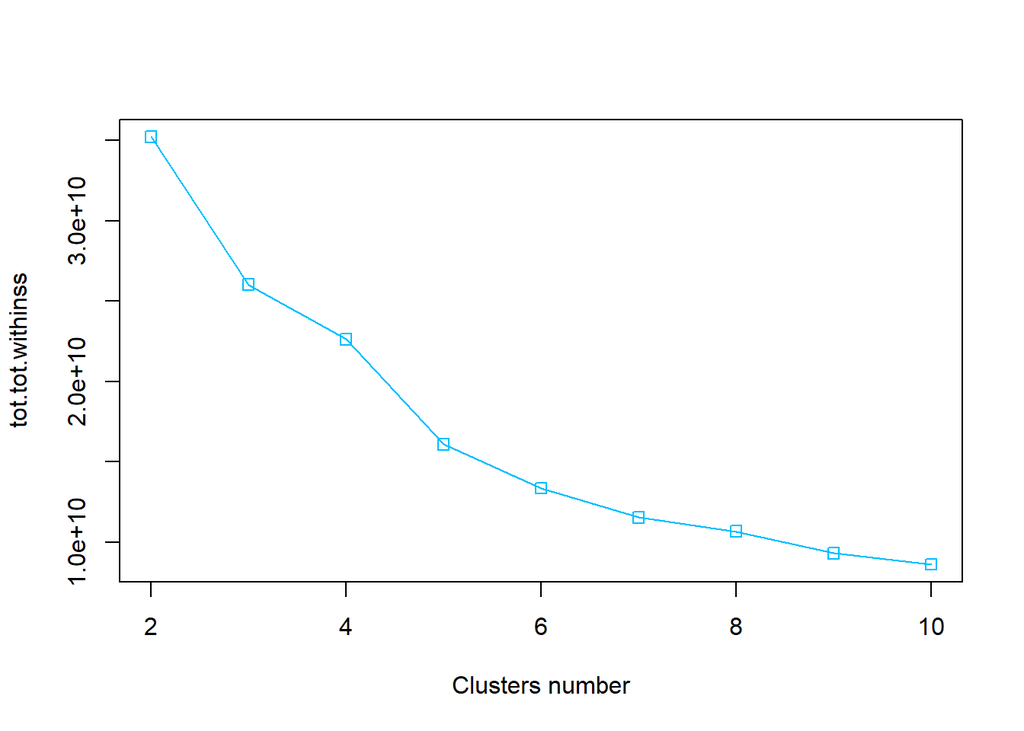

```r
results <- rep(0, 10)
for (i in c(2:10))
{
  fit <- kmeans(telecomNumericData, i)
  results[i] <- fit$tot.withinss
}
plot(2:10,results[2:10],type="o",col="deepskyblue",pch=0,xlab="Clusters number",ylab="tot.tot.withinss")
```

```r
if (!require('fpc')) install.packages('fpc')
library(fpc)
fit_ch  <- kmeansruns(telecomNumericData, krange = 1:10, criterion = "ch")
fit_asw <- kmeansruns(telecomNumericData, krange = 1:10, criterion = "asw")
fit_ch$bestk
```

```
## [1] 2
```

```r
fit_asw$bestk
```

```
## [1] 2
```

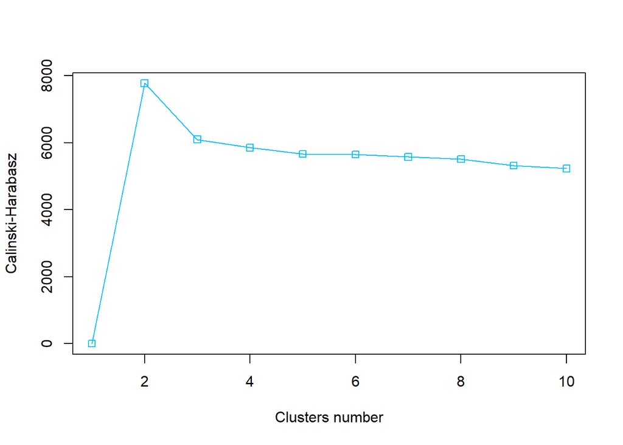

```r
plot(1:10,fit_ch$crit,type="o",col="deepskyblue",pch=0,xlab="Clusters number",ylab="Calinski-Harabasz")
```

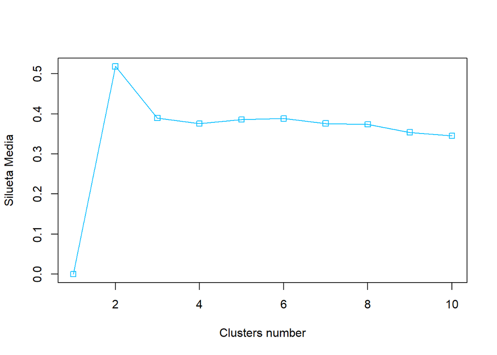

```r
plot(1:10,fit_asw$crit,type="o",col="deepskyblue",pch=0,xlab="Clusters number",ylab="Silueta Media")
```

In the elbow method, we can deduce that 5 would be a good value, since we can see how the graph begins to stabilize. However, in the mean silhouette and Calinski-Harabasz criteria, the best value in both is 2. Interestingly, both graphs are practically the same, with hardly any differences.

We can conclude first of all, that since two criteria suggest that 2 is the optimal value for the choice of clusters, testing first with this value and observing the results would be best. However, the other criterion should not be neglected either, and testing with 5 will give us other results and another view with which to compare our first result and see which is better for the project.